# Lecture 8

## Data Transformation

1. Modelling Needs
2. Better Visualisation
3. Better Interpretation

### 1. Mathematical Transformation

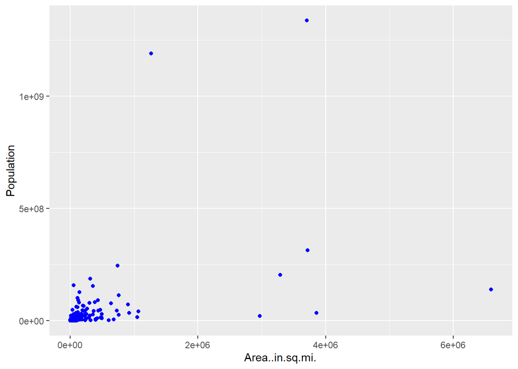

```r
library("ggplot2")
data = read.csv("./Data/area&population-raw.csv")
ggplot(data, aes(x=Area..in.sq.mi., y=Population)) + geom_point(colour="blue")
```

The visualisation is poor. Most points are concentrated in the bottom left corner, making it difficult to draw any reasonable conclusions. To figure out how to transform the data, we need to understand it first.

Density plot of area:

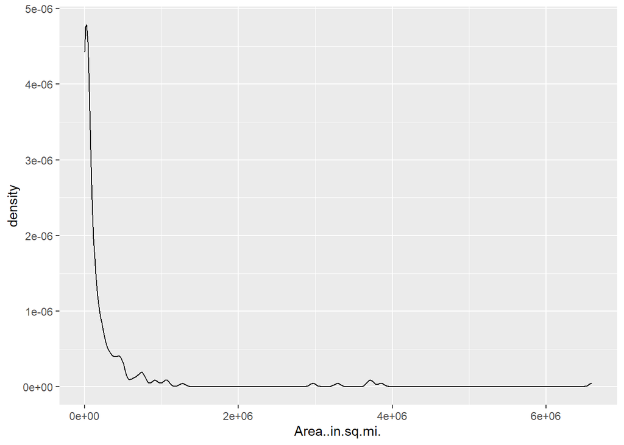

```r
ggplot(data, aes(x=Area..in.sq.mi.)) + geom_density()
```

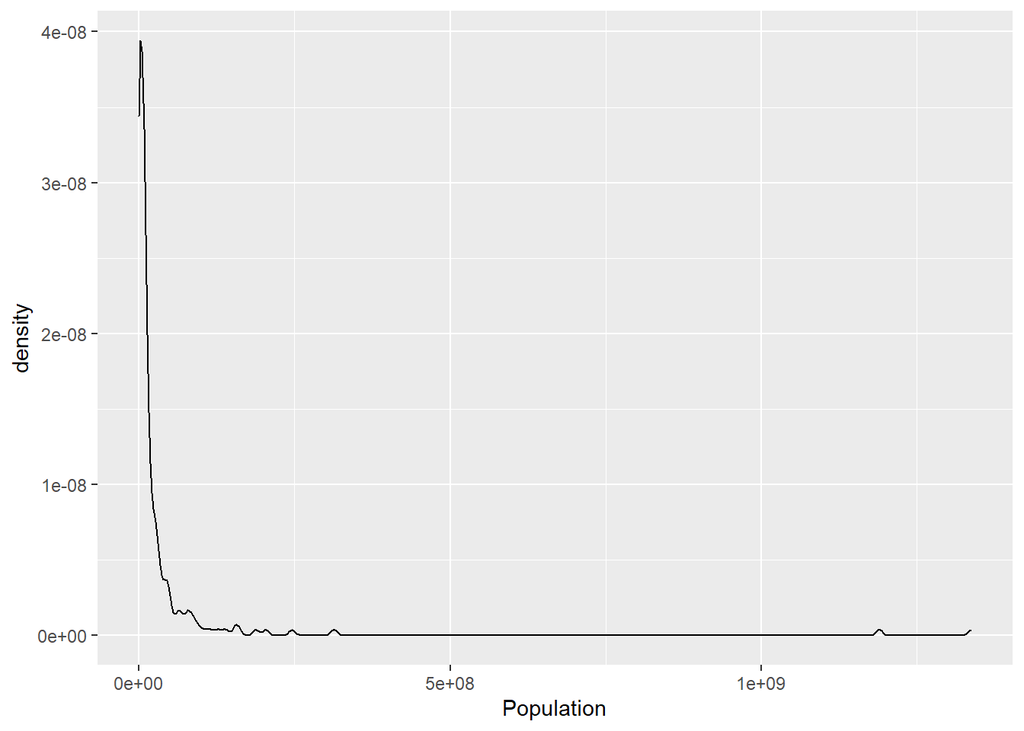

```r
ggplot(data, aes(x=Population)) + geom_density()
```

The graphs look logarithmic. We can now transform the graphs.

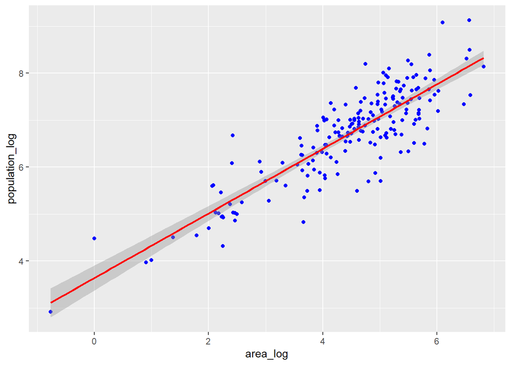

```r
data$area_log = log10(data$Area..in.sq.mi.)
data$population_log = log10(data$Population)

ggplot(data, aes(x=area_log, y=population_log)) + geom_point(colour="blue") + geom_smooth(method="lm", color="red")
```

### 2. Categorisation

Sometimes, data is split into categories. For numerical values, they are usually split into intervals of equal lengths.

Note that this method might carry risks. For example, 0-2 years old vs 20-22 years old. Babies change a lot in 3 years while young adults do not change as dramatically. We must always evaluate what the meaning of the intervals we choose.

Numerical values are also split along convenient numbers (e.g. 1-1000, 1000-5000). Such methods have no statistical foundation. This is also risky as there might not be a pronounced difference between the 2 groups (e.g. 999 vs 1001).

One way to base our categorisations is with visualisation:

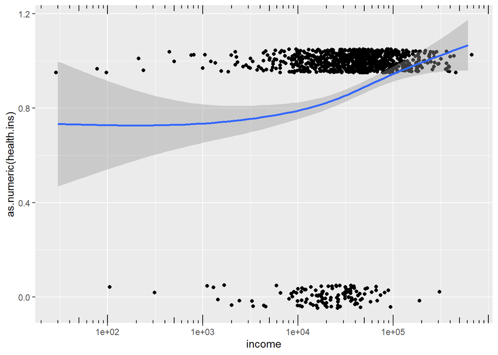

```r
custdata = read.table("./Data/custdata.tsv", sep="\t", header=T)

ggplot(custdata, aes(x=income, y=as.numeric(health.ins))) + geom_point(position=position_jitter(w=0.05, h=0.05)) + scale_x_log10(breaks=c(100,1000,10000,100000)) + geom_smooth() + annotation_logticks(sides="bt")
```

The blue line is the best fit line of customers’ likelyhood of buying insurance with respect to their income. It has a clear increase between 20,000 to 100,000. Hence, it is best to have 3 groups: <20000, 20000-100000, >100000.

### 3. Normalisation

When we want to compare data that is affected by other environmental factors that cause its weight to differ, we need to normalise it. For example, it is difficult to draw any reasonable conclusions about the income in Indonesia vs in Singapore using just the raw data. Other factors like exchange rate and purchasing power greatly affect our results.

We should instead use the median/mean as benchmarks within each country to normalise their respective income data.

```
# join data
custdata = merge(custdata, median.income, by.x="State.of.res", by.y="State")

# normalise
custdata$income.normalised = with(custdata, income/Per.Capita.Income)
```

## ggmap

ggmap is a package developed on top of ggplot2. Hence all plots from ggmap can be overlayed with plots from ggplot2.

```r
library(ggmap)
```

[figure not shown]

```r
ggmap::register_google(key='AIzaSyCnGFj3-tmhyhkx2Suxw3HNa6P0c0fjHc0')

m = get_map("Singapore", source="google", zoom=11, maptype="roadmap")
ggmap(m)
```

### Integrating with ggplot2

[figure not shown]

```r
pizzahut.location = read.csv("./Data/PizzaHut.csv", header=T, colClasses=c("character", "character", "factor", "character", "numeric", "numeric"))

# get singapore map
map = get_map("Singapore", zoom=11, source="google")
# plot latitude and longitude and combine with map
m1 = ggmap(m, base_layer = ggplot(data=pizzahut.location, aes(x=lon, y=lat)))

# plot points by region
m1 + geom_point(aes(color=Region))
```

### Region Borders

Sometimes, we want a map, not by the country but by the regions. This cannot be done with only ggmap. We will use **raster** and **rgdal**.

```r
library("raster")
library("rgdal")
library("XML")
```

```r
SG = getData('GADM', country="SG", level=1) # GADM is the source of the map data
class(SG) # SpatialPolygonsDataFrame
```

```
## [1] "SpatialPolygonsDataFrame"
## attr(,"package")
## [1] "sp"
```

```r
# Access elements using @
class(SG@data) # data frame
```

```
## [1] "data.frame"
```

```r
head(SG@data) # used to communicate with other data
```

```
##        GID_0    NAME_0   GID_1     NAME_1 VARNAME_1 NL_NAME_1 TYPE_1 ENGTYPE_1
## 260003   SGP Singapore SGP.1_1    Central      <NA>      <NA> Region    Region
## 260001   SGP Singapore SGP.2_1       East      <NA>      <NA> Region    Region
## 259999   SGP Singapore SGP.3_1      North      <NA>      <NA> Region    Region
## 260000   SGP Singapore SGP.4_1 North-East      <NA>      <NA> Region    Region
## 260002   SGP Singapore SGP.5_1       West      <NA>      <NA> Region    Region
##        CC_1 HASC_1
## 260003 <NA>   <NA>
## 260001 <NA>   <NA>
## 259999 <NA>   <NA>
## 260000 <NA>   <NA>
## 260002 <NA>   <NA>
```

```r
class(SG@polygons) # list
```

```
## [1] "list"
```

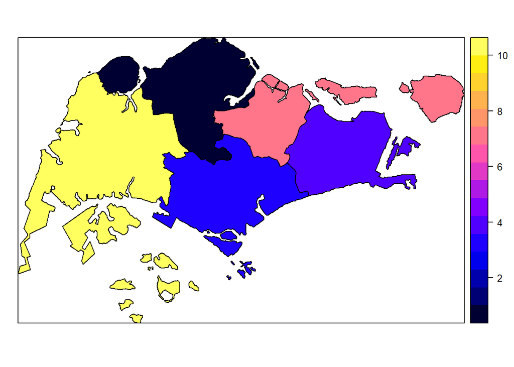

```r
# SG@polygons[1] # contains coordinate data about region boundaries

data = data.frame(Region=c("Central", "East", "North", "North-East", "West"),
                  value=c(3,4,1,7,10))
SG@data = merge(SG@data, data, by.x="NAME_1", by.y="Region")

# plot
spplot(SG, "value") # colours using values in the value column of SG@data
```

## leaflet

leaflet is an open-source javascript library for interactive maps.

```r
library("leaflet")
library("tidyverse")
```

```r
m = leaflet()

# adding a map layer
m = addTiles(m)

# adding markers
m = addMarkers(m, lat=1.239660, lng=103.835381, popup="Sentosa Cove")

# preset zooming level
m = setView(m, lat=1.239660, lng=103.835381, zoom=11)

m
```

[interactive chart not shown]

### Adding Multiple Markers

```r
df = read.csv("./Data/Singapore_Tourist_Locations.csv", colClasses=c("numeric", "numeric", "character"))
leaflet() %>% addTiles() %>% addMarkers(data=df, lng=~longitude, lat=~latitude, popup=~name)
```

[interactive chart not shown]

### Adding Clusters

```r
# showing clusters rather than individual points
leaflet() %>% addTiles() %>% addCircleMarkers(data=df, lng=~longitude, lat=~latitude,
                                              radius=5, clusterOptions=markerClusterOptions(),
                                              popup=~name)
```

[interactive chart not shown]

### Overlaying Plots

```r
library(htmlwidgets)

pizzahut.location = read.csv("./Data/PizzaHut.csv")
region.list = c("North", "East", "Central", "West")
colorFactors = colorFactor(c("red", "green", "blue"), domain=pizzahut.location$Region)

m = leaflet() %>% addTiles()

for (i in 1:4) {
  pizzahut.region = pizzahut.location[pizzahut.location$Region == region.list[i], ]

  m = addCircleMarkers(m, lng=pizzahut.region$lon, lat=pizzahut.region$lat,
                       radius=10, stroke=F, fillOpacity=1,
                       color = colorFactors(pizzahut.region$Region),
                       group=region.list[i]) # the group is to add the checkbox options later
}

# add map types
m = m %>% addTiles(group="Default") %>%
  addProviderTiles("Esri.WorldImagery", group="Esri") %>%
  addProviderTiles("Stamen.Toner", group="Toner") %>%
  addProviderTiles("Stamen.TonerLite", group="Toner Lite")

# add radio and checkbox controls
## base groups can only show 1 type at a time (radio)
## overlay groups can be shown together (checkbox)
m = addLayersControl(m, baseGroups=c("Default", "Esri", "Toner", "Toner Lite"),
                    overlayGroups=region.list)

saveWidget(m, file="m.html")
m
```

[interactive chart not shown]

### Plotting Polygons

```r
library(raster)

data = data.frame(Region=c("Central", "East", "North", "North-East", "West"),
                  value=c(3,4,1,7,10))
SG = getData("GADM", country="SG", level=1)
SG@data = merge(SG@data, data, by.x="NAME_1", by.y="Region")
popup = paste0("<strong>Name: </strong>", SG$Name_1)

# create numeric palette
pal = colorNumeric(palette="Blues", domain=SG$value)
m = leaflet() %>% addTiles() %>% addPolygons(data=SG, weight=2, stroke=T,
                                             smoothFactor=0.1, fillOpacity=0.8,
                                             color=~pal(value), popup=popup)
m
```

[interactive chart not shown]

```r
# create static palette
factpal = colorFactor(topo.colors(5), SG$value)
m = leaflet() %>% addTiles() %>% addPolygons(data=SG, weight=2, stroke=F,
                                             smoothFactor=0.2, fillOpacity=0.8,
                                             color=~factpal(value), popup=popup)
m
```

[interactive chart not shown]

### Generate Heatmap

```r
library("leaflet.extras")
```

```r
# heatmap based on number of earthquakes in each area
leaflet(quakes) %>% addProviderTiles(providers$CartoDB.DarkMatter) %>%
  addWebGLHeatmap(lng=~long, lat=~lat, size=60000) # size is in meters
```

[interactive chart not shown]

```r
# heatmap based on eartquake magnitude
leaflet(quakes) %>% addProviderTiles(providers$CartoDB.DarkMatter) %>%
  addWebGLHeatmap(lng=~long, lat=~lat, intensity=~mag, size=60000)
```

[interactive chart not shown]